# Projet d’Econométrie du Risque

Hadad Ahmed

15/01/2025

# 1 Introduction:

## 1.1 Contexte

Ce projet vise à analyser les données d’une mutuelle afin de mieux comprendre les comportements de ses adhérents en matière de durée de contrat. La variable principale étudiée est la durée entre la souscription et la rupture du contrat, un indicateur clé pour la mutuelle, car une tendance à la résiliation a été observée, souvent au profit d’autres mutuelles.

## 1.2 Objectifs

L’objectif est double :

1. Identifier les facteurs qui influencent la rupture de contrat en fonction des caractéristiques des adhérents (âge, statut de propriétaire, catégorie socio-professionnelle, etc.).
2. Prédire la durée d’un contrat à partir de ces variables explicatives, en s’appuyant sur des approches statistiques et de modélisation.

## 1.3 Etapes du projet

Le projet se déroule en trois étapes principales :

1. Analyse descriptive des données (statistiques descriptives univariées et bivariées) pour comprendre les profils des adhérents et leurs comportements.
2. Une analyse non-paramétrique à l’aide de l’estimateur de Kaplan-Meier et des tests de log-rank pour étudier les différences de survie entre groupes de profils.
3. La mise en œuvre de modèle de régression pour expliquer les raisons associées à la rupture du contrat et d’améliorer la compréhension des dynamiques sous-jacentes.

# 2 Analyse Descriptive:

## 2.1 Statistiques descriptives univariées

**Quelques Préalables au calcul des statistiques**

Avant de procéder à toute analyse, il convient de vérifier la struture des données pour s’assurer que les variables sont au bon format

```
  Obs AGE PROP PROF HOMME   DEBUT  FINOBS
1   1  49    0    5     1 2000,48 2010,66
2   2  57    0    6     1 2002,47  2015,8
3   3  37    0    5     1 2000,15 2010,23
4   4  44    0    2     1 2000,88  2015,8
5   5  60    1    7     1 2000,41 2010,31
6   6  58    1    8     1 2000,33 2006,17
```

```
'data.frame':   953 obs. of  7 variables:
 $ Obs   : int  1 2 3 4 5 6 7 8 9 10 ...
 $ AGE   : int  49 57 37 44 60 58 44 54 43 37 ...
 $ PROP  : int  0 0 0 0 1 1 1 1 1 1 ...
 $ PROF  : int  5 6 5 2 7 8 5 3 5 5 ...
 $ HOMME : int  1 1 1 1 1 1 1 1 1 1 ...
 $ DEBUT : chr  "2000,48" "2002,47" "2000,15" "2000,88" ...
 $ FINOBS: chr  "2010,66" "2015,8" "2010,23" "2015,8" ...
```

Le jeu de données contient 953 observations et 6 variables pertinentes (la colonne “obs” correspond aux observations et ne sera pas considérée ici comme une variable). Ces données sont relatives aux caractéristiques des adhérents et à leur historique de contrat. Voici les détails des variables :

- AGE : l’âge de l’adhérent en années.
- PROP : est-ce que l’adhérent est propriétaire de son logement ? 1 Oui, 0 Non.
- PROF : la catégorie socio-professionnelle de l’adhérent, qui prend 8 modalités, codées de la façon suivante: 1 agriculteur, 2 artisan, 3 cadre, 4 profession intermédiaire, 5 employé, 6 ouvrier, 7 retraité, 8 autre.
- HOMME : cette variable corresponds en réalité au SEXE de l’adhérent et prend pour modalités 1 s’il s’agit d’un homme et 0 si c’est une femme.
- DEBUT : représente la date (en années) où l’adhérent a souscrit à sa mutuelle
- FINOBS : soit la date (en années) où l’adhérent a arrêté sa souscription (si la date est inférieure à 2015.80), soit la date 2015.80, qui correspond à la date d’extraction des données, et qui signifie que la personne est toujours adhérente à la mutuelle.

**Ajustements nécessaires**

- Les variables “PROP”, “PROF” et “HOMME” seront converties facteur et HOMME sera renommée SEXE.
- Conversion des dates (DEBUT et FINOBS) en format numérique pour permettre des calculs.
- Calcul de la variable réponse : Une nouvelle variable, Duree_observee, sera créée pour mesurer la durée entre DEBUT et FINOBS en années.

```
'data.frame':   953 obs. of  8 variables:
 $ Obs           : int  1 2 3 4 5 6 7 8 9 10 ...
 $ AGE           : int  49 57 37 44 60 58 44 54 43 37 ...
 $ PROP          : Factor w/ 2 levels "0","1": 1 1 1 1 2 2 2 2 2 2 ...
 $ PROF          : Factor w/ 8 levels "1","2","3","4",..: 5 6 5 2 7 8 5 3 5 5 ...
 $ SEXE          : Factor w/ 2 levels "0","1": 2 2 2 2 2 2 2 2 2 2 ...
 $ DEBUT         : num  2000 2002 2000 2001 2000 ...
 $ FINOBS        : num  2011 2016 2010 2016 2010 ...
 $ Duree_observee: num  10.2 13.3 10.1 14.9 9.9 ...
```

```
           Obs            AGE           PROP           PROF           SEXE
             0              0              0              0              0
         DEBUT         FINOBS Duree_observee
             0              0              0
```

Les variables sont à présent bien spéficiées. Par ailleurs, le jeu de données ne comporte pas de valeurs manquantes. Nous pouvons passer aux analyses descriptives.

**1.Variable d’intérêt (Duree_observée)**

```
Résumé statistique pour Durée_observee :
```

```
   Min. 1st Qu.  Median    Mean 3rd Qu.    Max.
   1.33    7.26   11.54   10.77   14.75   15.80
```

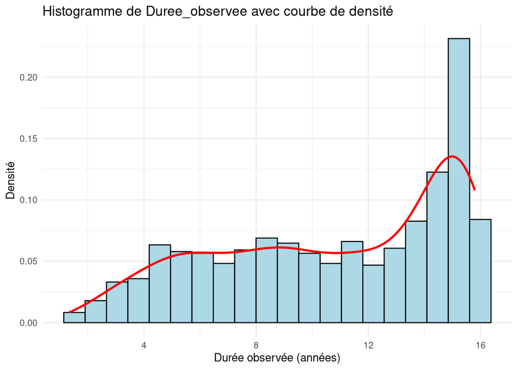

- Les adhérents résilient leurs contrats au bout de 10.77 ans en moyenne, avec des durées comprises entre 1.33 an et 15.8 ans.
- La distribution est asymétrique vers la gauche. Entre 4 et 12 ans, les barres de l’histogramme sont de faibles hauteurs, indiquant que peu d’adhérents résilient durant cette période. Le pic autour de 16 ans traduit une fidélité élevée, avec une proportion importante d’adhérents atteignant cette durée avant de résilier.

**2. Age des adhérents**

```
Statistiques descriptives pour l'âge :
```

```
   Min. 1st Qu.  Median    Mean 3rd Qu.    Max.
   6.00   39.00   45.00   44.82   51.00   69.00
```

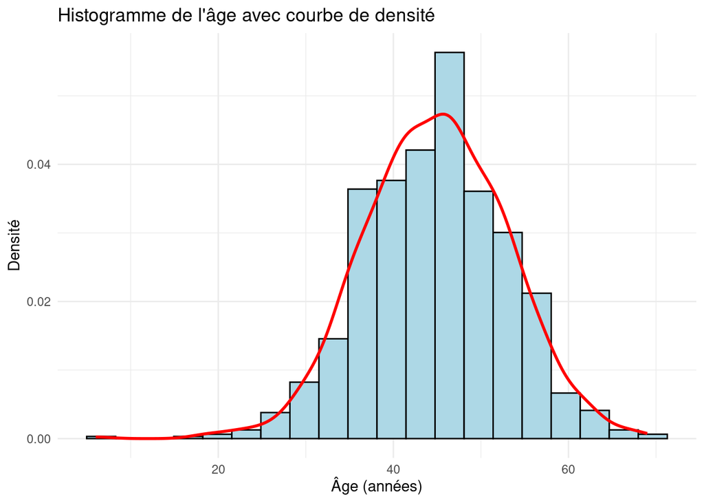

**3. Sexe**

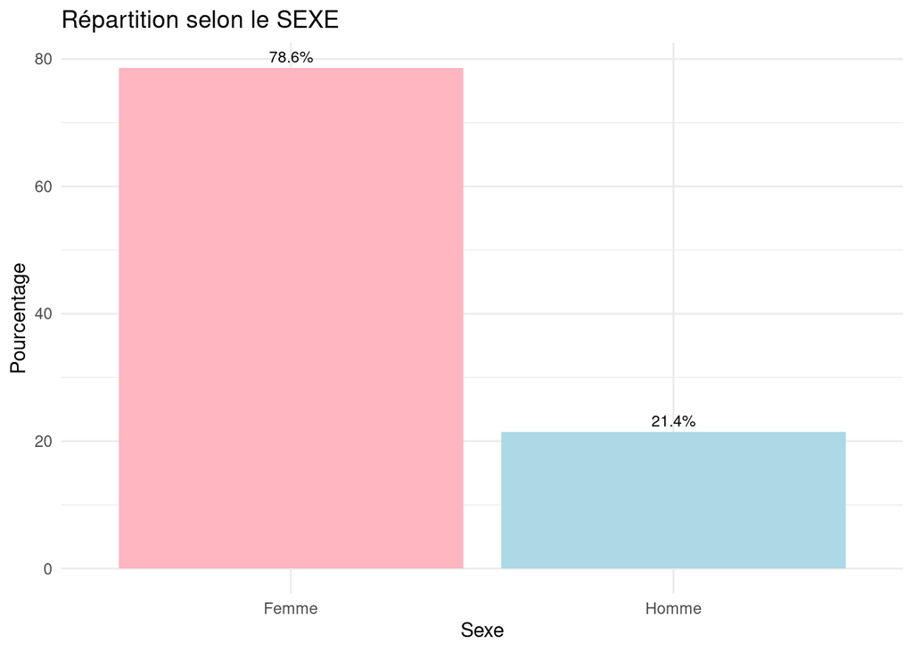

Les adhérents sont en majorité des femmes (78.6%).

**4. Propriétaire ou non**

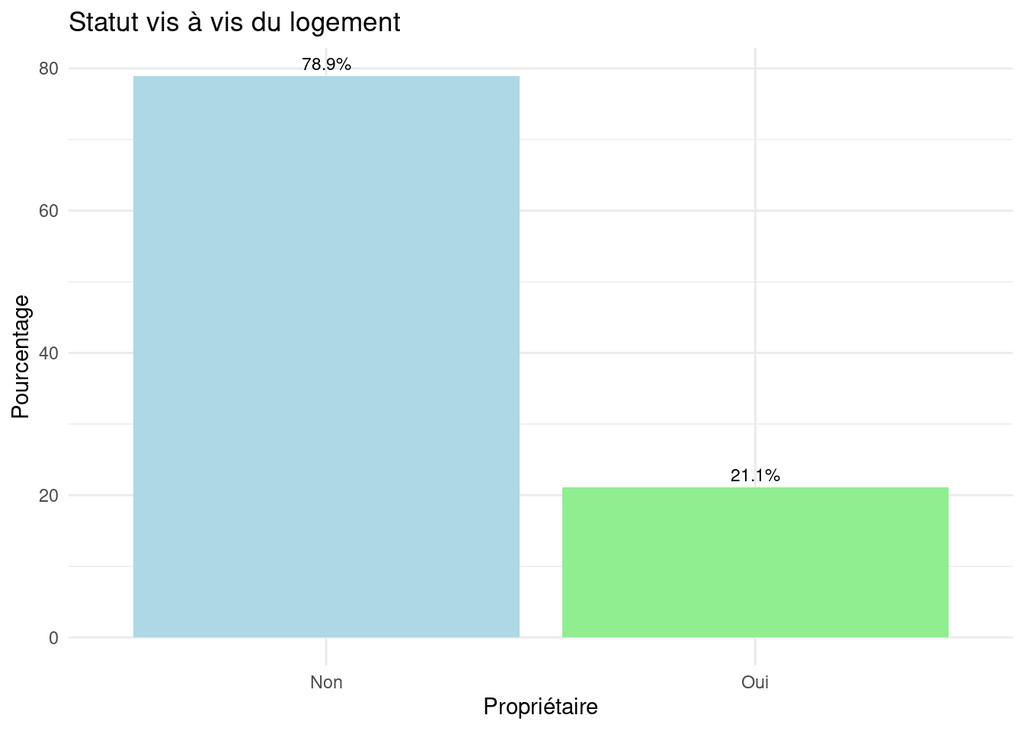

Environ 21% des adhérents sont propriétaires de leur logement.

**5. Catégorie Socio-Professionnelle (CSP)**

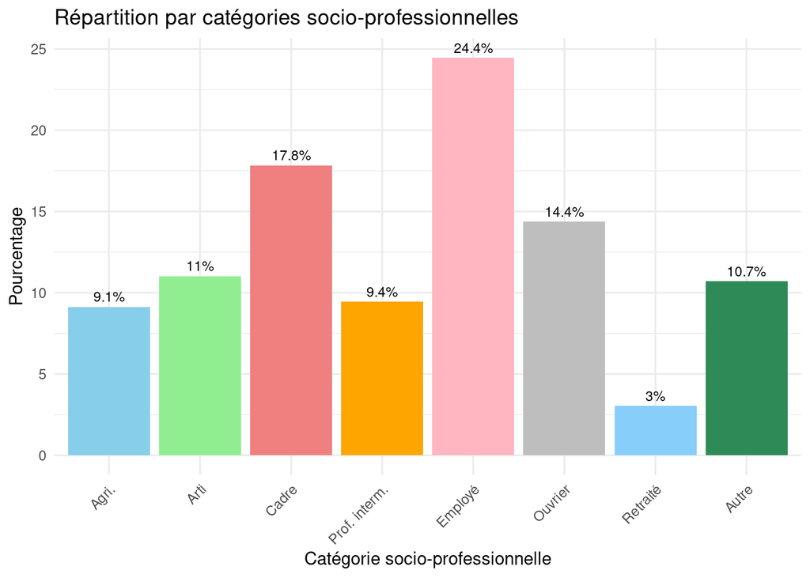

- Les CSP les plus représentées sont les employés, suivi des cadres et des ouvriers (24.4%, 17.8% et 14.4% respectivement)
- Les CSP les moins représentées sont les retraités, les agriculteurs et les professions intermédiaires (3%, 9.1% et 9.4%) respectivement.

## 2.2 Statistiques descriptives bivariées

Dans cette partie, nous étudierons la relation entre la Durée observée et les covariables.

**1. Duree_observee et Age**

Nous ferons un test de corrélation et ensuite un graphique de la distribution Duree observée en fonction de l’âge

```
    Pearson's product-moment correlation

data:  mutuelle$Duree_observee and mutuelle$AGE
t = 5.6585, df = 951, p-value = 2.02e-08
alternative hypothesis: true correlation is not equal to 0
95 percent confidence interval:
 0.1183290 0.2412164
sample estimates:
      cor
0.1804769
```

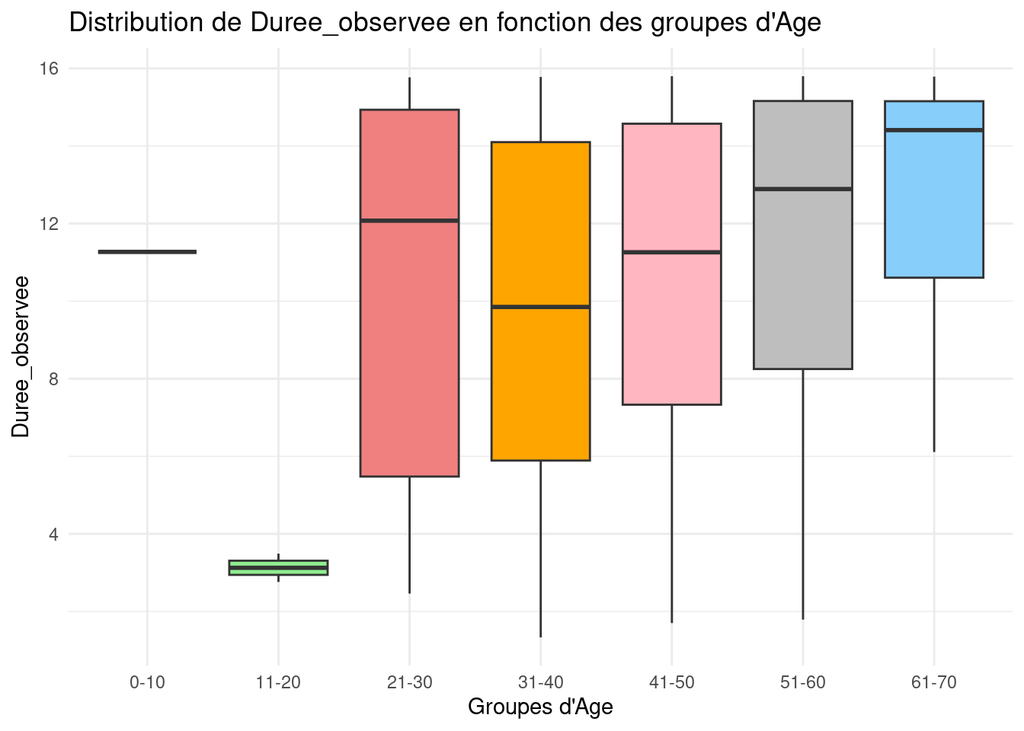

- Le test de corrélation de Pearson a mis en évidence l’existence d’une corrélation signifiative entre l’âge et la durée de résiliation. ll s’agit d’une corrélation faible positive (0.18).
- Le choix naturel de graphique aurait été un nuage de points puisque les 2 variables sont numériques. Mais, une représentation de l’âge en classe, permettrait de voir dans quelle tranche d’âge on résilie le plus tôt ou le plus tard.
- Nous remarquons que les adhérents dans les tranches âge **51-60** et **61-70** mettent en moyenne plus de temps pour résilier leurs contrats. Les adhérents dont contrats sont les vite résiliés ont entre **11 et 20 ans**.

Pour les covariables qualitatives, nous ferons d’abord un test ANOVA pour voir s’il existe une différence significative des durées de résiliation en fonctions des modalités des variables. Ensuite, nous ferons un graphique afin d’observer les distributions conditionnelles

**2. Duree_observee et SEXE**

```
             Df Sum Sq Mean Sq F value   Pr(>F)
SEXE          1    514   514.4   30.77 3.77e-08 ***
Residuals   951  15898    16.7
---
Signif. codes:  0 '***' 0.001 '**' 0.01 '*' 0.05 '.' 0.1 ' ' 1
```

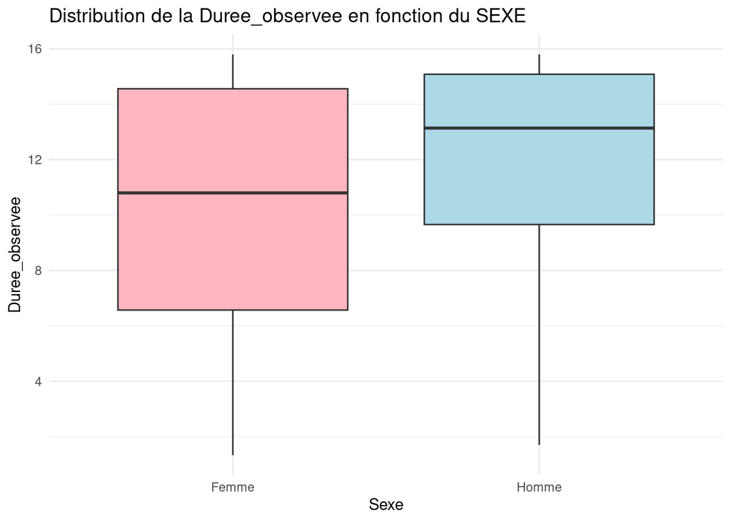

- La p-valeur du test est très significative, ce qui implique que les durées de résiliation diffèrent significativement selon le genre.
- Ce résultat se confirme graphiquement, avec les femmes qui résilient en moyenne plus vite leurs contrats, que les hommes.

**3. Duree_observee et PROP**

```
             Df Sum Sq Mean Sq F value Pr(>F)
PROP          1      0   0.349    0.02  0.887
Residuals   951  16412  17.258
```

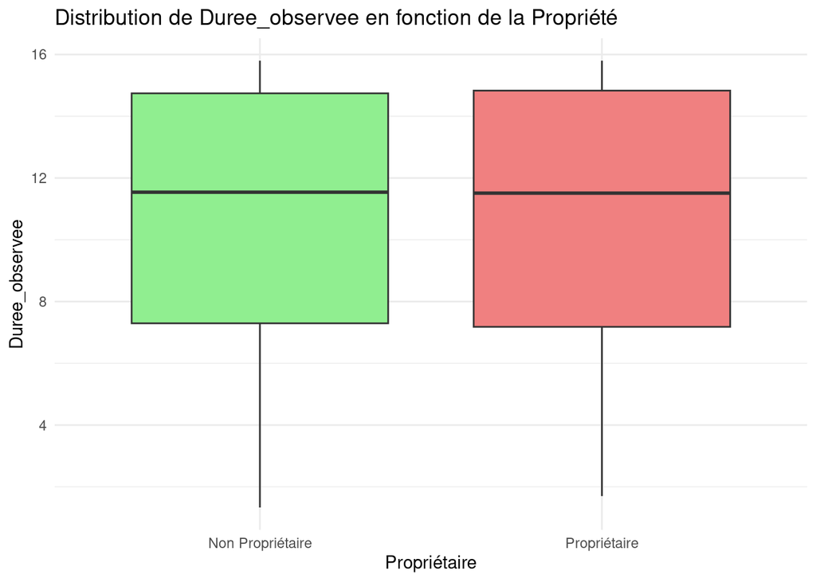

La p-valeur du test ANOVA, vaut 0.88 (largement supérieure au seuil de 5%). Il n’existe donc pas de différence significative entre les durées de résiliation moyennes: que l’adhérent soit proporiétaire ou non. C’est d’ailleurs ce que confirme le graphique.

**4. Duree_observee et PROF**

```
                 Df Sum Sq Mean Sq F value Pr(>F)
as.factor(PROF)   7   2601   371.5   25.42 <2e-16 ***
Residuals       945  13812    14.6
---
Signif. codes:  0 '***' 0.001 '**' 0.01 '*' 0.05 '.' 0.1 ' ' 1
```

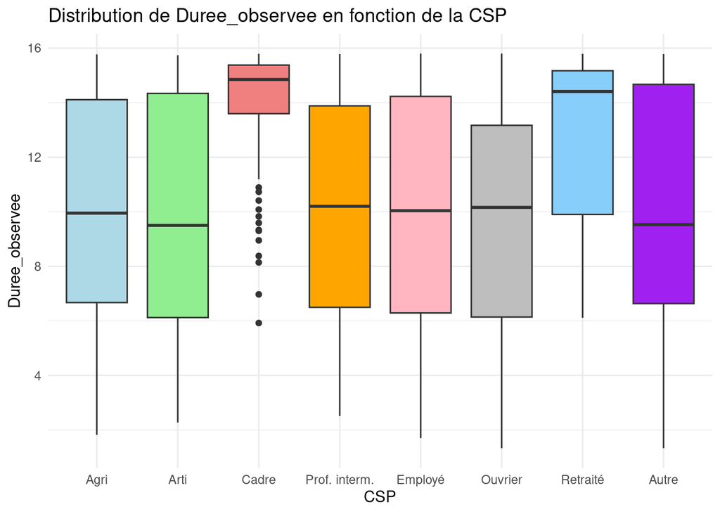

- La p-valeur du test ANOVA est très significative, ce qui suggère qu’il existe une différence significative entre les durées de résiliation au sein des catégories socio-professionnelles.
- On remaqrue que les **cadres** mettent en moyenne plus de temps à résilier leur contrat comparativement au reste de la population. Les adhérents des CSP, **“Profession Intermédiaire”, “Employé”, et “Ouvrier”**, mettent en moyenne le même temps pour résilier leur contrat.

## 2.3 Résumé de l’analyse descriptive

L’analyse montre que l’âge, le sexe et la profession sont corrélées à la durée de résiliation des contrats. Les jeunes (11-20 ans) résilient rapidement, tandis que les groupes plus âgés (51-60 et 61-70 ans) résilient plus tard, avec des durées moyennes plus longues. En termes de profession, les cadres prennent plus de temps pour résilier, tandis que les employés et ouvriers ont une durée similaire. Enfin, le statut de propriétaire n’affecte pas la durée de résiliation.

# 3 Estimateur de Kaplan-Meier et tests du log-rang:

L’estimateur de Kaplan-Meier est une estimation de la fonction de survie des contrat des adhérants à partir de données de temps censurées, c’est à dire à partir des données des adhérents qui n’ont pas rompu leurs contrat jusqu’à sa fin.

$\textbf{Indicateur de censure :}$

Dans l’approche de Kaplan-Meier, il est essentiel d’identifier le temps observé et de déterminer si un adhérent est censuré ou non.

$\bullet$ Le temps observé est déjà défini dans la colonne “Durée_observé”, qui correspond à la durée entre la date de début de souscription (DEBUT) et la date de fin observée (FINOBS).

$\bullet$ L’indicateur de censure est une variable binaire précisant si l’événement (rupture de contrat) a été observé ou non :

$\textbf{Définitions :}$

```
  Obs AGE PROP PROF SEXE   DEBUT  FINOBS Duree_observee AGE_group censure
1   1  49    0    5    1 2000.48 2010.66          10.18     41-50       1
2   2  57    0    6    1 2002.47 2015.80          13.33     51-60       0
3   3  37    0    5    1 2000.15 2010.23          10.08     31-40       1
4   4  44    0    2    1 2000.88 2015.80          14.92     41-50       0
5   5  60    1    7    1 2000.41 2010.31           9.90     61-70       1
6   6  58    1    8    1 2000.33 2006.17           5.84     51-60       1
```

```
 La moyenne des données censurées est de: 0.6316894
```

$\textbf{Construire de l'estimateur Kaplan-Meier :}$

```
Call: survfit(formula = surv_obj ~ 1, data = mutuelle)

  time n.risk n.event survival std.err lower 95% CI upper 95% CI
  1.33    953       2    0.998 0.00148        0.995        1.000
  1.70    951       1    0.997 0.00181        0.993        1.000
  1.72    950       1    0.996 0.00209        0.992        1.000
  1.79    949       1    0.995 0.00234        0.990        0.999
  1.82    948       1    0.994 0.00256        0.989        0.999
  1.96    947       1    0.993 0.00277        0.987        0.998
  2.01    946       1    0.992 0.00296        0.986        0.997
  2.22    945       1    0.991 0.00313        0.984        0.997
  2.26    944       1    0.990 0.00330        0.983        0.996
  2.27    943       1    0.988 0.00346        0.982        0.995
  2.29    942       1    0.987 0.00361        0.980        0.995
  2.39    941       1    0.986 0.00376        0.979        0.994
  2.46    940       1    0.985 0.00390        0.978        0.993
  2.48    939       1    0.984 0.00403        0.976        0.992
  2.51    938       1    0.983 0.00416        0.975        0.991
  2.54    937       2    0.981 0.00441        0.973        0.990
  2.59    935       1    0.980 0.00453        0.971        0.989
  2.71    934       1    0.979 0.00464        0.970        0.988
  2.75    933       1    0.978 0.00476        0.969        0.987
  2.76    932       1    0.977 0.00486        0.967        0.986
  2.79    931       1    0.976 0.00497        0.966        0.986
  2.93    930       2    0.974 0.00518        0.964        0.984
  3.01    928       1    0.973 0.00528        0.962        0.983
  3.03    927       2    0.971 0.00547        0.960        0.981
  3.04    925       1    0.970 0.00556        0.959        0.981
  3.05    924       1    0.969 0.00566        0.957        0.980
  3.06    923       1    0.967 0.00575        0.956        0.979
  3.07    922       1    0.966 0.00584        0.955        0.978
  3.11    921       2    0.964 0.00601        0.953        0.976
  3.12    919       1    0.963 0.00609        0.951        0.975
  3.14    918       1    0.962 0.00618        0.950        0.974
  3.15    917       1    0.961 0.00626        0.949        0.974
  3.23    916       1    0.960 0.00634        0.948        0.973
  3.24    915       1    0.959 0.00642        0.947        0.972
  3.27    914       1    0.958 0.00650        0.945        0.971
  3.28    913       1    0.957 0.00657        0.944        0.970
  3.36    912       1    0.956 0.00665        0.943        0.969
```

[output cut: 428 more lines]

```
 14.63    255       1    0.372 0.01608        0.342        0.405
 14.68    249       1    0.371 0.01608        0.340        0.404
 14.71    245       1    0.369 0.01609        0.339        0.402
 14.83    233       2    0.366 0.01610        0.336        0.399
 14.86    229       1    0.364 0.01611        0.334        0.397
 14.87    227       1    0.363 0.01612        0.332        0.396
 15.01    207       1    0.361 0.01614        0.331        0.394
 15.02    206       1    0.359 0.01616        0.329        0.392
 15.03    204       2    0.356 0.01619        0.325        0.389
 15.05    196       1    0.354 0.01621        0.324        0.387
 15.11    183       1    0.352 0.01623        0.322        0.385
 15.16    176       1    0.350 0.01626        0.319        0.383
 15.35    139       1    0.347 0.01634        0.317        0.381
 15.38    129       1    0.345 0.01643        0.314        0.379
 15.48    109       1    0.342 0.01658        0.311        0.376
```

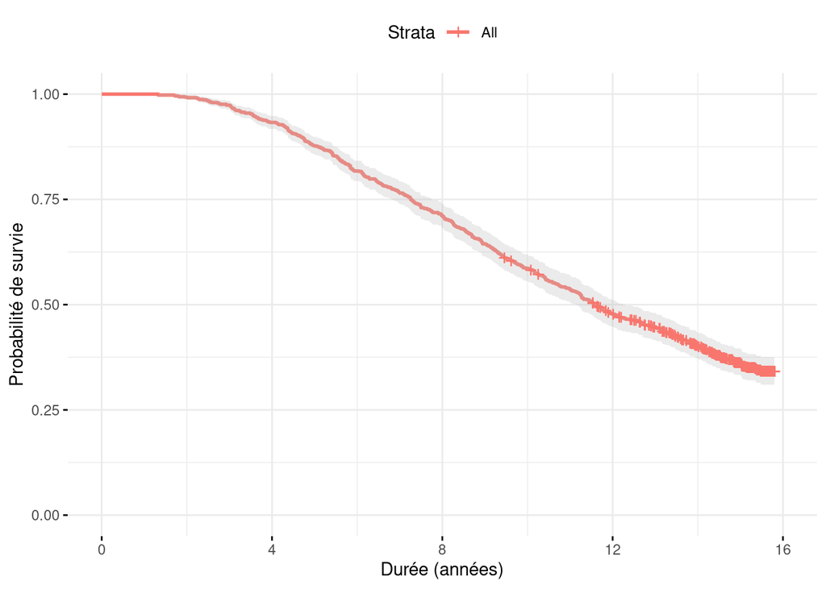

Tout au long de la fonction de survie, l’intervalle de confiance est très étroit, ce qui indique que l’estimation de la fonction de survie est précise.

A partir des 12 ans la courbe de survie est assez faible qui montre une dimuntion important des adhérents.

```
50% des adhérents ont résilié leurs contrat après : 11.57 ans (mediane de la survie).
```

$\textbf{Test de log-rank}$

On cherche à déterminer si la probabilité de survie diffère de manière significative entre les groupes des profils (par exemple, selon l’âge, le sexe, ou d’autres variables). Cela nous permet de detecter le profil d’adhérent qui a tendence à avoir un contrat plus long.

On teste l’hypothèse nulle suivante :

$H_0$: Les groupes ont des fonctions de survie identique,

contre

$H_1$ : Les groupes n’ont pas des fonctions de survie identique,

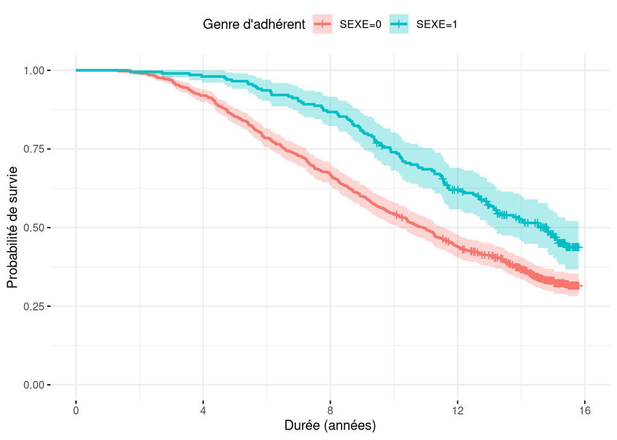

```
Call:
survdiff(formula = surv_obj ~ SEXE, data = mutuelle)

         N Observed Expected (O-E)^2/E (O-E)^2/V
SEXE=0 749      497      449       5.2      20.5
SEXE=1 204      105      153      15.2      20.5

 Chisq= 20.5  on 1 degrees of freedom, p= 6e-06
```

Les courbes de Kaplan-Meier montrent que :

$\bullet$ Les hommes ont une durée de contrat plus longue avec une courbe de survie au-dessus de celle des femmes.

$\bullet$ Cette différence confirme que le genre est un facteur significatif influençant la durée des contrats.

$\bullet$ Les intervalles de confiance étroits assurent la précision des estimations.

On remarque 497 ruptures de contrat chez les femme d’un nombre total des femme de 749 soit 66% des femmes, contre 105 ruptures de contrat chez chez les hommes d’un nombre total d’hommes 204 soit 51%. Cela montre que les hommes ont tendense à rester sous contrats par rapport aux femmes.

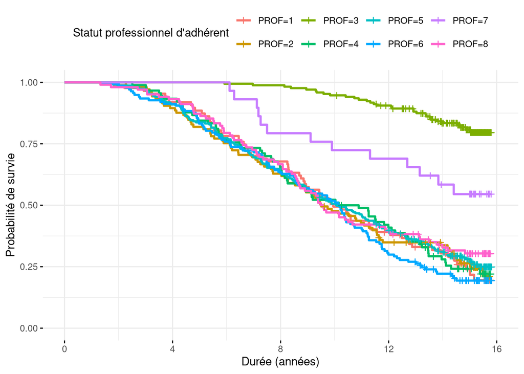

```
Call:
survdiff(formula = surv_obj ~ PROF, data = mutuelle)

         N Observed Expected (O-E)^2/E (O-E)^2/V
PROF=1  87       66     49.3      5.68      6.19
PROF=2 105       77     57.1      6.94      7.68
PROF=3 170       31    158.9    102.95    142.55
PROF=4  90       68     51.1      5.59      6.12
PROF=5 233      168    131.2     10.30     13.21
PROF=6 137      109     72.5     18.35     20.97
PROF=7  29       13     23.2      4.45      4.64
PROF=8 102       70     58.7      2.16      2.40

 Chisq= 160  on 7 degrees of freedom, p= <2e-16
```

Les hypothèses sont telles que:

$H_0$ : les fonctions de survies sont identiques pour toutes les CSP,

contre

$H_1$ : Il existe au moins une CSP qui diffère des autres par la courbe de survie,

Les observations incluent :

$\bullet$ Les cadres et retraités ont une durée de contrat plus longue, leurs courbes de survie étant supérieures à celles des autres profils. On observe 31 ruptures des contrats dans 170 cadres soit 18% des cadres qui ont rompu leurs contrats, un taux tres faibles et 13 ruptures dans 29 retraités soit 44% des retraités ont rompu leurs contrat. Des taux de ruptures moin significatives surtout pour les cadres.

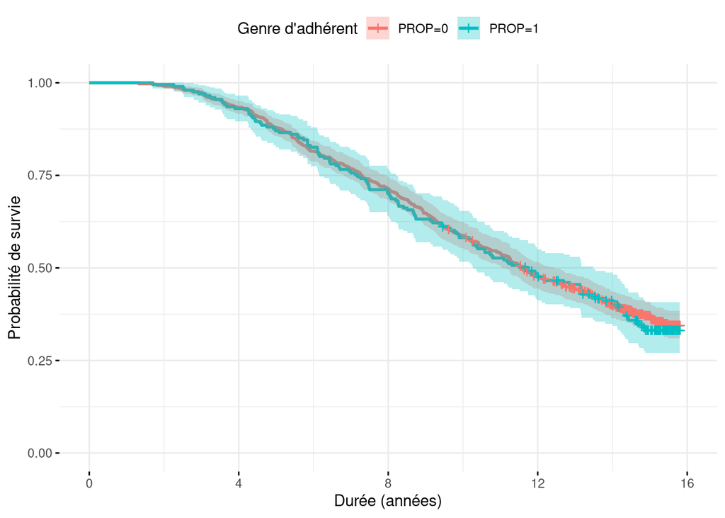

```
Call:
survdiff(formula = surv_obj ~ PROP, data = mutuelle)

         N Observed Expected (O-E)^2/E (O-E)^2/V
PROP=0 752      472      476    0.0275     0.131
PROP=1 201      130      126    0.1035     0.131

 Chisq= 0.1  on 1 degrees of freedom, p= 0.7
```

Contrairement aux facteurs précédents, le test de log-rank donne un p-valeur = 0,7 suppérieur à 0.05 avec une satistique de test $\chi²(1) = 0.1$ assez faible, et cela ne révèle aucune différence significative entre propriétaires et non-propriétaires.

Les courbes de Kaplan-Meier montrent que :

$\bullet$ Les courbes des deux groupes sont presque identiques, confirmant que le statut de propriétaire n’a pas d’impact sur la durée des contrats.

$\bullet$ Les intervalles de confiance étroits garantissent également des estimations fiables, mais l’absence de différence statistique indique que ce facteur n’est pas pertinent dans ce contexte.

$\textbf{Conclusion sur l'estimateur de Kaplan-Meier, tests du log-rank}$

Les analyses révèlent que certains facteurs, comme le genre et le statut professionnel, ont des effet significatifs dans la durée des contrats. En revanche, le statut de propriétaire, n’ont pas d’impact statistiquement significatif. Les courbes de Kaplan-Meier et les intervalles de confiance montrent que les estimations sont précises, appuyant la robustesse de ces résultats. Ces observations peuvent orienter des stratégies ciblées pour améliorer la rétention des adhérents.

Cela donne ainsi une vision globale des decideurs, qui pourraient envisager par exemple de fidélisations chez les profils des bonnes fois commes les hommes et les cadres, et aussi envisager des offres spécifiques chez les autres qui ont tendenses à ne pas rester longtemps sous contrat comme les femmes, les agriculteurs.

# 4 Modèle de régression:

Mise en œuvre de modèle de régression pour expliquer les raisons associées à la rupture du contrat et d’améliorer la compréhension des dynamiques sous-jacentes.

$\textbf{Régression de Cox (modèle de survie)}$

Le modèle de Cox est un modèle de régression qui évalue l’impact des variables sur le taux de risque d’un événement dans notre cas l’evenement est la rupture de contrat.

Dans notre étude de survie de Kaplan-Meier, nous avons constaté que le genre et le statut professionnel, ont des effet significatifs dans la durée des contrats. En revanche, le statut de propriétaire, n’ont pas d’impact statistiquement significatif. Nous allons donc partir par elaborer deux modeles dans ce sens, et comparer leurs significativité.

## 4.1 Un modèle avec uniquement les variables significatives (AGE, SEXE, PROF):

$$h(t) = h_0(t) \cdot \exp(\theta_1 \cdot
age + \theta_2 \cdot sexe + \theta_3 \cdot prof )$$

```
Call:
coxph(formula = Surv(Duree_observee, censure) ~ AGE + SEXE +
    PROF, data = mutuelle)

  n= 953, number of events= 602

           coef exp(coef)  se(coef)      z Pr(>|z|)
AGE   -0.025151  0.975163  0.005454 -4.612 3.99e-06 ***
SEXE1 -0.473157  0.623032  0.107915 -4.385 1.16e-05 ***
PROF2 -0.002772  0.997231  0.168063 -0.016    0.987
PROF3 -1.945790  0.142874  0.218174 -8.919  < 2e-16 ***
PROF4  0.022454  1.022708  0.173051  0.130    0.897
PROF5 -0.038856  0.961889  0.145328 -0.267    0.789
PROF6  0.182633  1.200373  0.156500  1.167    0.243
PROF7 -0.365759  0.693670  0.322962 -1.133    0.257
PROF8 -0.064683  0.937364  0.172106 -0.376    0.707
---
Signif. codes:  0 '***' 0.001 '**' 0.01 '*' 0.05 '.' 0.1 ' ' 1

      exp(coef) exp(-coef) lower .95 upper .95
AGE      0.9752     1.0255   0.96479    0.9856
SEXE1    0.6230     1.6051   0.50426    0.7698
PROF2    0.9972     1.0028   0.71737    1.3863
PROF3    0.1429     6.9992   0.09316    0.2191
PROF4    1.0227     0.9778   0.72853    1.4357
PROF5    0.9619     1.0396   0.72347    1.2789
PROF6    1.2004     0.8331   0.88329    1.6313
PROF7    0.6937     1.4416   0.36834    1.3063
PROF8    0.9374     1.0668   0.66898    1.3134

Concordance= 0.677  (se = 0.011 )
Likelihood ratio test= 248  on 9 df,   p=<2e-16
Wald test            = 159.8  on 9 df,   p=<2e-16
Score (logrank) test = 198  on 9 df,   p=<2e-16
```

$\bullet$ Sur les 953 observations (n=953), on a observé 602 ruptures de contrats, soit $63\%$, (number of events= 602).

$\bullet$ On a $\hat \theta_1 = -0.025$ qui donne un rapport de risque de $\exp(\hat \theta_1) = 0.97$ Cela reflète une tendance selon laquelle les adhérents plus âgés sont légèrement moins susceptibles de rompre leur contrat. Cette effet de l’age sur le risque est significatif avec une p-valeur de $3.99e-06$.

$\bullet$ On a un effet $\hat \theta_2 = -0.47$ qui donne un rapport de risque de $\exp(\hat \theta_2) = 0.62 < 1$ cela dit que le risque de rupture de contrat chez les hommes est 0.62 moin fois chez les femmes. Les hommes semblent être plus engagés que les femmes dans leurs contrats d’adhésion. Cette effet de sexe sur le risque est significatif avec une p-valeur de $1.16e-05$.

$\bullet$ On a un effet $\hat \theta_{3} = -1.94$ chez les cadres qui donne un rapport de risque de $\exp(\hat \theta_3) = 0.14 < 1$ cela dit que le risque de rupture de contrat chez les cadres est 0.14 moin fois chez les agriculteurs. Cette effet des cadres sur le risque est significatif avec une p-valeur de $< 2e-16$.

Dans l’analyse de Kaplan-Meier nous avons constaté que se sont les cadres et les retraités qui ont tendances à avoir des durées de survie importantes. ça serait donc interessant de comparer leurs rapport de risque:

$\bullet$ Le rapport de risque entre un cadre et un retraité vaut:

$\exp(\hat \theta_{cadre} - \hat \theta_{retraité}) = \exp(-1.945790 - (-0.365759)) = 0.205 < 1$ cela dit que le risque de rupture de contrat chez les cadres est 0.205 moin fois chez les retraités. Cela confirme la solidité de l’engagement des cadres par rapport à une autre catégorie fortement engagée, les retraités. Cette effet concorde avec l’analyse de Kaplan-Meier qu’on a observé, la courbe de survie chez les cadres est au dessus de celle des retraités montrant un engagement à long termes chez les cadres.

La concordance est de 0.677, ce qui montre que le modèle distingue bien les observations ayant des temps de survie différents. C’est une performance satisfaisante.

## 4.2 Un modèle avec toutes les variables (AGE, SEXE, PROF, PROP):

$$h(t) = h_0(t) \cdot \exp(\theta_1 \cdot
age + \theta_2 \cdot sexe + \theta_3 \cdot prof + \theta_4 \cdot prop
)$$

```
Call:
coxph(formula = Surv(Duree_observee, censure) ~ AGE + SEXE +
    PROF + PROP, data = mutuelle)

  n= 953, number of events= 602

           coef exp(coef)  se(coef)      z Pr(>|z|)
AGE   -0.028890  0.971523  0.005696 -5.072 3.94e-07 ***
SEXE1 -0.480104  0.618719  0.108003 -4.445 8.78e-06 ***
PROF2 -0.009564  0.990482  0.168139 -0.057   0.9546
PROF3 -1.961335  0.140671  0.218303 -8.984  < 2e-16 ***
PROF4  0.002457  1.002460  0.173320  0.014   0.9887
PROF5 -0.037783  0.962921  0.145353 -0.260   0.7949
PROF6  0.162619  1.176588  0.156865  1.037   0.2999
PROF7 -0.416642  0.659257  0.323751 -1.287   0.1981
PROF8 -0.070622  0.931814  0.172169 -0.410   0.6817
PROP1  0.250792  1.285043  0.105965  2.367   0.0179 *
---
Signif. codes:  0 '***' 0.001 '**' 0.01 '*' 0.05 '.' 0.1 ' ' 1

      exp(coef) exp(-coef) lower .95 upper .95
AGE      0.9715     1.0293    0.9607    0.9824
SEXE1    0.6187     1.6162    0.5007    0.7646
PROF2    0.9905     1.0096    0.7124    1.3771
PROF3    0.1407     7.1088    0.0917    0.2158
PROF4    1.0025     0.9975    0.7137    1.4080
PROF5    0.9629     1.0385    0.7242    1.2803
PROF6    1.1766     0.8499    0.8652    1.6001
PROF7    0.6593     1.5169    0.3495    1.2435
PROF8    0.9318     1.0732    0.6649    1.3058
PROP1    1.2850     0.7782    1.0440    1.5817

Concordance= 0.681  (se = 0.011 )
Likelihood ratio test= 253.4  on 10 df,   p=<2e-16
Wald test            = 164.7  on 10 df,   p=<2e-16
Score (logrank) test = 202.6  on 10 df,   p=<2e-16
```

Au dela l’analyse faite dans le modèle 1, le rapport de risque pour les propriétaires est supérieur à celui des non-propriétaires (HR = 1.285). Cela indique que les propriétaires sont plus susceptibles de connaître l’événement d’intérêt (rupture de contrat) que les non-propriétaires.

$\textbf{ d) Comparaison des deux modèles}$

On effectue un test de rapport de vraisembance pour comparer les deux modeles:

$H_0$ : Le modèle restreint (“cox_model1”) est suffisant pour décrire les données (l’ajout des covariables n’apporte pas d’amélioration significative).

$H_1$ : Le modèle complet (“cox_model2”) décrit significativement mieux les données que le modèle restreint (“cox_model1”)

```
Analysis of Deviance Table
 Cox model: response is  Surv(Duree_observee, censure)
 Model 1: ~ AGE + SEXE + PROF
 Model 2: ~ AGE + SEXE + PROF + PROP
   loglik  Chisq Df Pr(>|Chi|)
1 -3732.1
2 -3729.4 5.3986  1    0.02015 *
---
Signif. codes:  0 '***' 0.001 '**' 0.01 '*' 0.05 '.' 0.1 ' ' 1
```

- La p-valeur du test vaut 0.02015 (inférieur à 0.05), ce qui suggère qu’il existe une différence significative entre les deux modèles. On constate que le modèle 2 maximise la log-vraissemblance (-3729.4) contre -3732.1 pour le modèle 1.
- Cela suggère qu’être propriétaire ou non (PROP) est un facteur pertinent pour expliquer la rupture des contrats.

## 4.3 Validation du mode=èle retenu:

Un bon modèle de COX doit verifier certains hypothèses pour etre validé. L’hypothèse la plus importante et générale est celle $\textbf{des risques proportionnels}$:

Pour chaque covariable son effet de risque doit être constant au cours du temps. C’est à dire que $\theta_i$ ne doit pas dépendre du temps.

On pose alors le problème comme suit:

$$\theta_i = \theta_{i1} + \theta_{i2}
\cdot g(t)$$

où

- $\theta_{i1}$ est l’effet constant de la covariable i,
- $\theta_{i1}$ est le terme d’interaction entre la covariable i et le temps,
- $g(t)$ est une fonction du temps.

On pose les hypothèses:

$H_0$ : L’effet de la variable i ne depend pas du temps, c’est à dire $\theta_{i2} = 0$

$H_1$ : L’effet de la variable i depend du temps, c’est à dire $\theta_{i2} \neq 0$

$$\textbf{test de Schoenfeld}$$

```
        chisq df       p
AGE     9.301  1  0.0023
SEXE   15.709  1 7.4e-05
PROF   17.101  7  0.0168
PROP    0.288  1  0.5917
GLOBAL 43.368 10 4.3e-06
```

$\bullet$ Les variables AGE, SEXE, et PROF montrent une violation de l’hypothèse de risques proportionnels (p-valeur < 0.05).

$\bullet$ La variable PROP satisfait l’hypothèse de risques proportionnels (p-valeur > 0.05).

Le test global $(p=4.3×10−6)$ montre que l’hypothèse des risques proportionnels est violée dans le modèle. Le modèle $\textbf{cox_model2}$ ne respecte pas l’hypothèse clé des risques proportionnels. Cela signifie que certains effets de covariables (notamment AGE, SEXE, et PROF) varient au cours du temps. Par conséquent, nous allons stratifier les covariables qui violent l’hypothèse dans le modèle. Cela permet de modéliser des risques de base différents pour chaque groupe:

$\textbf{Modèle stratifié:}$:

```
       chisq df    p
PROP    2.58  1 0.11
GLOBAL  2.58  1 0.11
```

Le test de proportionnalité des risques pour PROP et l’indice global montre des p-valeurs élevées $(p = 0.11)> 0.05$. Ce test accepte l’hypothèse nulle, ce qui signifie qu’après stratification des variables AGE, SEXE, et PROF, l’hypothèse des risques proportionnels n’est plus violée.

```
Call:
coxph(formula = Surv(Duree_observee, censure) ~ strata(AGE) +
    strata(SEXE) + PROP + strata(PROF), data = mutuelle)

  n= 953, number of events= 602

        coef exp(coef) se(coef)     z Pr(>|z|)
PROP1 0.2265    1.2542   0.1438 1.575    0.115

      exp(coef) exp(-coef) lower .95 upper .95
PROP1     1.254     0.7974    0.9462     1.662

Concordance= 0.519  (se = 0.014 )
Likelihood ratio test= 2.44  on 1 df,   p=0.1
Wald test            = 2.48  on 1 df,   p=0.1
Score (logrank) test = 2.49  on 1 df,   p=0.1
```

$\textbf{Modèle d'interaction avec le temps d'observation:}$

Au lieu de stratifier, nous pouvons envisager d’introduire des interactions explicites entre les covariables et le temps. Cela permet de modéliser explicitement comment l’effet de ces variables évolue avec le temps et d’avantage capturer cet effet. Cela pourrait améliorer le modele et eviter la violation du risque proportionnel.

L’âge (AGE) est un facteur clé dans les analyses de survie, car les risques peuvent évoluer différemment en fonction de l’âge des individus. Par exemple, les individus plus âgés pourraient présenter des risques accrus sur des périodes longues ou courtes.

Pour capturer cet effet dynamique, nous allons introduire l’interaction **AGE * Durée_observé** dans le modèle. Voici les résultats principaux :

```
                    chisq df    p
AGE                1.6294  1 0.20
Duree_observee     1.3356  1 0.25
SEXE               0.0888  1 0.77
PROP               0.0178  1 0.89
PROF               5.1434  7 0.64
AGE:Duree_observee 0.1976  1 0.66
GLOBAL             9.9641 12 0.62
```

$\textbf{Comparaisons des modèles:}$

```
Analysis of Deviance Table
 Cox model: response is  Surv(Duree_observee, censure)
 Model 1: ~ AGE + SEXE + PROF + PROP
 Model 2: ~ strata(AGE) + strata(SEXE) + PROP + strata(PROF)
 Model 3: ~ AGE * Duree_observee + SEXE + PROP + PROF
   loglik   Chisq Df Pr(>|Chi|)
1 -3729.4
2  -563.3 6332.27  9  < 2.2e-16 ***
3  -330.5  465.62 11  < 2.2e-16 ***
---
Signif. codes:  0 '***' 0.001 '**' 0.01 '*' 0.05 '.' 0.1 ' ' 1
```

L’interaction **AGE * Durée_observé** améliore significativement l’ajustement du modèle (selon l’ANOVA) et respecte les hypothèses de proportionnalité des risques (test de Schoenfeld non significatif).

$\textbf{Problème avec d'autres interactions:}$

Lorsque nous tentons d’introduire des interactions entre le temps (Duree_observee) et d’autres variables (par exemple, SEXE ou PROF), le modèle produit des résultats invalides (valeurs NaN dans le test de Schoenfeld). La cause exacte de ce problème peut être liée à une multicolinéarité ou à une mauvaise spécification des interactions, mais ces interactions ne semblent pas robustes ou informatives.

Nous conservons donc le modèle avec l’interaction **AGE * Duree_observee** uniquement, car :

- Il est robuste et valide les hypothèses des risques proportionnels.
- Il améliore significativement l’ajustement du modèle.
- Il repose sur une interprétation claire et pertinente, tout en évitant les problèmes rencontrés avec d’autres interactions.

```
Call:
coxph(formula = Surv(Duree_observee, censure) ~ AGE * Duree_observee +
    SEXE + PROP + PROF, data = mutuelle)

  n= 953, number of events= 602

                         coef  exp(coef)   se(coef)       z Pr(>|z|)
AGE                 1.457e-02  1.015e+00  7.050e-03   2.067   0.0388 *
Duree_observee     -7.360e+01  1.088e-32  3.662e+00 -20.100   <2e-16 ***
SEXE1              -5.048e-02  9.508e-01  1.466e-01  -0.344   0.7306
PROP1               1.107e-01  1.117e+00  1.350e-01   0.820   0.4125
PROF2               3.097e-03  1.003e+00  1.710e-01   0.018   0.9856
PROF3              -6.286e-01  5.333e-01  2.297e-01  -2.737   0.0062 **
PROF4               1.238e-01  1.132e+00  1.733e-01   0.714   0.4751
PROF5              -1.557e-02  9.846e-01  1.238e-01  -0.126   0.8999
PROF6               3.880e-02  1.040e+00  1.496e-01   0.259   0.7954
PROF7              -1.724e-01  8.417e-01  3.473e-01  -0.496   0.6196
PROF8              -2.691e-02  9.734e-01  1.811e-01  -0.149   0.8819
AGE:Duree_observee -1.477e-03  9.985e-01  7.265e-04  -2.033   0.0421 *
---
Signif. codes:  0 '***' 0.001 '**' 0.01 '*' 0.05 '.' 0.1 ' ' 1

                   exp(coef) exp(-coef) lower .95 upper .95
AGE                1.015e+00  9.855e-01 1.001e+00 1.029e+00
Duree_observee     1.088e-32  9.188e+31 8.317e-36 1.424e-29
SEXE1              9.508e-01  1.052e+00 7.133e-01 1.267e+00
PROP1              1.117e+00  8.952e-01 8.573e-01 1.456e+00
PROF2              1.003e+00  9.969e-01 7.174e-01 1.402e+00
PROF3              5.333e-01  1.875e+00 3.400e-01 8.366e-01
PROF4              1.132e+00  8.836e-01 8.058e-01 1.590e+00
PROF5              9.846e-01  1.016e+00 7.725e-01 1.255e+00
PROF6              1.040e+00  9.619e-01 7.754e-01 1.394e+00
PROF7              8.417e-01  1.188e+00 4.262e-01 1.662e+00
PROF8              9.734e-01  1.027e+00 6.826e-01 1.388e+00
AGE:Duree_observee 9.985e-01  1.001e+00 9.971e-01 9.999e-01

Concordance= 1  (se = 0 )
Likelihood ratio test= 7051  on 12 df,   p=<2e-16
Wald test            = 421.5  on 12 df,   p=<2e-16
Score (logrank) test = 2159  on 12 df,   p=<2e-16
```

**Effets significatifs:**

**AGE : HR = 1.015**, cela signifie qu’une augmentation d’une unité de l’âge (par exemple, un an) augmente le risque de résiliation de $1,5\%$. Cet effet est statistiquement significatif (p=0.0388 < 0.05). Cela peut indiquer que les personnes plus âgées sont légèrement plus à risque de résiliation au début (1,5% de risque supplémentaire par an).

Cependant avec **l’interaction AGE:Duree_observee : Coefficient −0.0015, HR=0.9985**, cela signifie que l’effet de l’âge diminue légèrement avec le temps. Donc on peut dire que chez les clients âgés, le risque de résiliation est donc initialement plus élevé, mais diminue plus vite que chez les jeunes clients.

**Durée_observé : HR ≈ 0**, cela traduit une forte diminution du risque à mesure que le temps d’observation augmente. Cette variable capte essentiellement l’effet du temps. Cela peut refléter une stabilisation de la relation entre l’adhérent et la mutuelle: plus le contrat dure, moins il y a de risque qu’il soit résilié.

**PROF3** : Les adhérent ayant un statut proffetionnel de cadre sont significativement moin risqués, c’est à dire ont moin de probabailité de resiliation de leurs contrats (HR=0.533, p=0.0062) que les agriculteurs ( catégorie initial: PROF = 1).

**Effets non significatifs :**

Les variables **SEXE, PROP**, et les autres catégories de **PROF** ne montrent pas d’effet significatif sur le risque.

**Qualité du modèle :**

Le modèle est globalement significatif (p<2e−16).

$\textbf{Conclusion sur le modèle de COX}$

**Choix du modèle:**

Le modèle met en évidence un effet significatif de l’âge, du temps et de la catégorie professionnelle “Cadre” sur le risque. Les autres variables n’ont pas d’impact notable dans ce contexte. Ces résultats pourraient guider des actions ciblées en fonction de l’âge et des profils professionnels.

# 5 Modèle Acceleration Failure Time (AFT):

Contrairement au modèle de COX (qui est semi-paramétrique), le modèle AFT est paramétrique et part de l’hypothèse que la durée de survie suit une distribution spécifique, comme : Exponential, Weibull, Log-logistique, Log-normale, etc.

L’objectif est de modéliser la durée (ou le logarithme de la durée) en fonction des covariables, avec l’idée que ces covariables accélèrent ou ralentissent la durée attendue avant la rupture. On modélise sous la forme :

$$\log(\tilde T)=X \cdot \beta + \epsilon$$

- $\tilde T$ : la durée de survie
- $X$ : les covariables (AGE, SEXE, PROP, PROF),
- $\beta$ : les coefficients à estimer,
- $\epsilon$ : une erreur aléatoire suivant une distribution spécifique (Weibull, log-normale, etc.).

Le modèle est dit “accélération” car les covariables agissent comme un facteur multiplicatif sur la durée de survie.

Nous allons tester deux modèles l’un avec la loi de **weibull** et l’autre avec la loi de **Log-normale

```
                  df      AIC
aft_model_weibull 12 4124.576
aft_model_lognorm 12 4066.191
```

```
                  df      BIC
aft_model_weibull 12 4182.892
aft_model_lognorm 12 4124.506
```

Avec un AIC et BIC plus faible, le modele avec la loi log-normal est mieux adaptée.

```
Call:
survreg(formula = Surv(Duree_observee, censure) ~ AGE + SEXE +
    PROF + PROP, data = mutuelle, dist = "lognormal")
               Value Std. Error      z       p
(Intercept)  1.42759    0.14855   9.61 < 2e-16
AGE          0.01874    0.00303   6.18 6.4e-10
SEXE1        0.30158    0.05543   5.44 5.3e-08
PROF2       -0.00483    0.09269  -0.05   0.958
PROF3        0.99297    0.09811  10.12 < 2e-16
PROF4        0.00903    0.09599   0.09   0.925
PROF5       -0.00171    0.08018  -0.02   0.983
PROF6       -0.06034    0.08738  -0.69   0.490
PROF7        0.16852    0.15746   1.07   0.285
PROF8        0.02064    0.09361   0.22   0.825
PROP1       -0.12268    0.05632  -2.18   0.029
Log(scale)  -0.48220    0.03061 -15.75 < 2e-16

Scale= 0.617

Log Normal distribution
Loglik(model)= -2021.1   Loglik(intercept only)= -2164.6
    Chisq= 286.96 on 10 degrees of freedom, p= 8.8e-56
Number of Newton-Raphson Iterations: 4
n= 953
```

**Statistiques globales :**

$\bullet$ **Log-likelihood (modèle complet) : −2021.1**, ce qui montre une amélioration par rapport au modèle nul (-2164.6).

**Interprétation des coefficients:**

$\bullet$ **AGE** Coefficient = 0.01874, significatif (p = 6.4e-10). Pour chaque unité d’augmentation de l’âge, le logarithme du temps de survie augmente, ce qui indique que les adhérents plus âgés tendent à avoir des temps de survie plus longs.

$\bullet$ **SEXE1** Coefficient = 0.30158, significatif (p = 5.3e-08). Cela suggère que les hommes ont un temps de survie plus long par rapport aux femmes.

$\bullet$ **PROF** : Effets très variables :

**PROF3** (Coefficient = 0.99297, p < 2e-16) : Les adhérent de catégorie professionnelle **Cadre** ont généralement un temps de survie nettement plus long que les agriculteurs ( **PROF = 1**) et certainement de meme pour les autres catégorie proffetionnelle.

**PROF2, PROF4, PROF5, PROF6, PROF7, PROF8** : Effets non significatifs (p>0.05), ce qui suggère que ces catégories n’ont pas un effet significatifs sur les durées de contrat.

$\bullet$ **PROP1** Coefficient = -0.12268, significatif (p = 0.029). Cela indique que les adhérents avec **PROP=1** (les proprietaires de leurs maisons) ont une durée de survie plus courte (accélération de la rupture).

$\textbf{Conclusion par rapport au modèle AFT}$

Le modèle AFT avec une distribution log-normale est le mieux adapté pour expliquer les durées de survie. Les variables significatives sont :

$\bullet$ Les variables **AGE, SEXE, PROF3**, et **PROP1** ont un effet significatif sur le temps de survie. **AGE** et **SEXE** augmentent le temps de survie.

$\bullet$ Effet d’**AGE** : Les clients plus âgés semblent avoir des durées de contrat plus longues.

$\bullet$ Effet du **SEXE** : Les hommes ont des durées de contrat plus longues que les femmes.

$\bullet$ PROF3 (Cadres) : Cette catégorie professionnelle a des durées de contrat significativement plus longues.

$\bullet$ Effet de **PROP** (Propriétaires) : Les adhérent propriétaires de leurs maisons ont des durées de contrat plus courtes que ceux non-propriétaires.

# 6 Conclusion générale:

Ce projet a permis d’analyser les données d’une mutuelle afin de mieux comprendre les facteurs influençant la durée des contrats des adhérents et d’identifier les profils à risque de résiliation. Grâce à une combinaison d’approches descriptives, non-paramétriques et de modélisation, plusieurs enseignements majeurs ont été dégagés:

**Estimateur de Kaplan-Meier et tests log-rank:**

Les analyses non-paramétriques ont confirmé que des variables comme le sexe et la catégorie professionnelle impactent significativement la durée des contrats, tandis que le statut de propriétaire ne présente pas d’effet significatif. Les courbes de survie montrent que les **cadres** et les **hommes** ont une probabilité de résiliation plus faible sur la durée. Ces résultats offrent une base solide pour orienter les stratégies de fidélisation vers les segments les plus à risque.

**Modèles de régression (Cox et AFT):**

Les modèles de régression ont affiné la compréhension des dynamiques sous-jacentes :

- Le modèle de **COX** a montré un effet significatif de l’âge (HR = 1,015) : les adhérents plus âgés sont initialement plus à risque de résiliation, mais cet effet diminue avec le temps. Les **cadres** (HR = 0,533) sont également moins susceptibles de résilier leurs contrats.
- Le modèle **AFT** a révélé que les adhérents plus âgés, les hommes, et les cadres ont des durées de contrat plus longues. En revanche, les propriétaires de leurs logements présentent une durée de contrat plus courte, ce qui suggère un comportement spécifique à cette catégorie.

**Implications stratégiques:**

Ces résultats offrent des pistes concrètes pour la mutuelle :

- **Stratégies de fidélisation ciblées :** Mettre en place des offres spécifiques pour les segments les plus à risque, comme les femmes et certaines catégories professionnelles (agriculteurs, employés).
- **Optimisation des campagnes :** Renforcer la fidélisation des profils stables (hommes, cadres, retraités) par des avantages durables, tout en étudiant les besoins spécifiques des propriétaires pour comprendre leur plus grande propension à résilier.